```python
import gymnasium as gym
import sumo_rl
import numpy as np
```

# SARSA algorithm

```python
def epsilon_greedy_policy(environment, q_table, state, action_space,epsilon):
    num_actions = environment.action_space.n
    if str(state) not in q_table:
            q_table[str(state)] = [0 for _ in range(num_actions)]

    if np.random.rand() < epsilon:
            action = environment.action_space.sample()
    else:
            action = np.argmax(q_table[str(state)])



    return action
```

```python
def greedy_policy(environment,q_table, state):
    num_actions = environment.action_space.n
    if str(state) not in q_table:
        q_table[str(state)] = [0 for _ in range(num_actions)]
    action = np.argmax(q_table[str(state)])
    return action
```

```python
q_array_history = []
alpha_history = []

def sarsa(environment, alpha=0.1, alpha_factor=0.9995, gamma=0.99, epsilon=0.5):

    #initial states:
    s  = environment.reset()
#     num_states = environment.observation_space.n
    num_actions = environment.action_space.n
    # Initial Q table

    q_array = {str(s): [0 for _ in range(num_actions)]}
    if str(s) not in q_array:
            q_array[str(s)] = [0 for _ in range(num_actions)]

    q_array_history.append(q_array.copy())
    alpha_history.append(alpha)

    # Update alpha
    if alpha_factor is not None:
        alpha = alpha * alpha_factor

    a = epsilon_greedy_policy(environment,q_array,str(s),environment.action_space, epsilon)

    end = False

    while not end:

        s_, r_,  terminated, truncated, info = environment.step(a)
        a_ = epsilon_greedy_policy(environment,q_array,str(s_),environment.action_space, epsilon)
        if str(s) not in q_array:
            q_array[str(s)] = [0 for _ in range(num_actions)]
        if str(s_) not in q_array:
            q_array[str(s_)] = [0 for _ in range(num_actions)]

        q_array[str(s)][a]  = q_array[str(s)][a]+  alpha*(r_ + gamma*q_array[str(s_)][a_]-q_array[str(s)][a])

        s = s_
        a = a_
        end  = terminated or truncated

    return q_array
```

## Main idea

In this environment, we have non-stationary states, where the states change during time when trafics come. As a reuslt, in the begining, we can't create a fixed-size list to store all the q-values. Instead, we used a dictionary to store them and update their value accordingly. Each time when we encontered a new state, we will add its q-value in the dictionary.

During the project, we've set a parameter called "num_seconds", this is because our enviroment doesn't have an end, the traffic keeps going until we close the environment. If we don't cut the process after a proper time, there will be no end for our learning processes. Therefore, we've choose "num_seconds" to decide when shall the agent stop learning.

# Experiments 1 : Single intersection road

In this case, the agent is trained with SARSA algorithm for different duration, including 1000s, 5000s, 10000s, 20000s. After training, we can get the corresponding q-table.

Then we tested our trained agent on the same road map, during 1000s.

We would like to know which parameter can be used to evaluate the performence of our agent, so we are testing total waiting time and average speed of the vehicles on the road as an indicator.

Total waiting time (s) is the sum of waiting time of all the vehicles at each time step. Average speed time is the average speed of the vehicles at this each step.

First take a look at the averaged values of these paremeters over the whole tesing process.

in our case, the goal is to minimizing the waiting time of the vehicules and let the vehicles moves at higer speed. It is commun that vehicles would move faster if they spend less time for waiting at the intersection. We can see that when waiting time is long, the speed is low.

```
* Agent trained by 1000s SARSA : T = 299s ; v = 3.08 m/s
* Agent trained by 5000s SARSA : T = 151s ; v = 3.63 m/s
* Agent trained by 10000s SARSA : T= 139s ; v = 3.87 m/s
* Agent trained by 20000s SARSA : T = 95s ; v = 4.21 m/s
```

It is shown that if we executed SARSA using a higher num_seconds, the waiting time decreases and speed will increase because the agent could have learned the q-values unders more diverse states, thus have a better "knowledge" of the q-table.

Then we plotted the total waiting time and speed at each time step during the testing. From this fig, we can see that SARSA trained during 1000s is not suitable enough for this sigle intersection study. This is because it haven't learned enough states, so the q-table does not contain much state-action pairs for the agent to choose, when it is being tested, it'll make random choice.

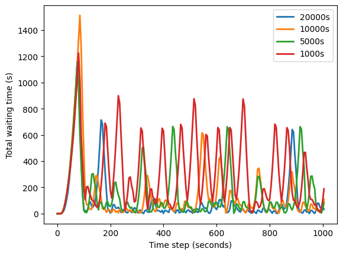

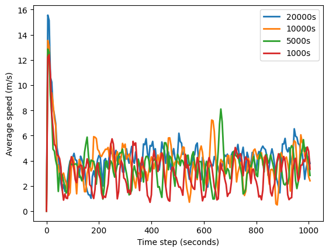

# Experiments 2 : 2x2grid

In this case, the agent is trained with SARSA algorithm for different duration, including 1000s, 5000s, 10000s.

Average speed of the vehicles:

```
* Agent trained by 1000s SARSA : v = 2.23 m/s
* Agent trained by 5000s SARSA :  v = 2.48 m/s
* Agent trained by 10000s SARSA : v = 2.52 m/s
```

The conclusion is similar to the previous experiment on single intersection environment. As trainning time increase, the speed of vehicles get higher. And 10000 seconds's learning is sufficient in this case. We also plotted the speed at each time step during the testing.

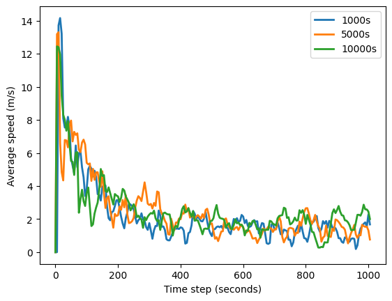

From this fig, SARSA agent trained during 1000s is not suitable, when we use this agent, the it's performence (average speed at each time step) is lower compared to other agents. Agent trained duing 10000s performs slightly better than the 5000s tranning. AS a result, for this 2x2 grid, training the SARSA Agent for 10000s will be sufficient.

Also, the average speed on single intersection is higher than 2x2 grid, this is because the road is much more complexe for this 2x2 grid.

```python
def evaluate_policy(q_array,net_file,route_file,output,num_seconds = 1000):

    reward_list = []
    num_seconds = num_seconds
    env = gym.make('sumo-rl-v0',
                    net_file=net_file,
                    route_file=route_file,
                    out_csv_name='outputs/single-intersection/output.csv',
                    use_gui=False,
                    num_seconds=num_seconds)
    state, info = env.reset()
    done = False
    while not done:
        action = greedy_policy( env,q_array,state)
        state, reward,  terminated, truncated, info = env.step(action)
        reward_list.append(reward)
        done = terminated or truncated
    env.save_csv(output,1)
    env.close()
```

build ennvironment

```python
env = gym.make('sumo-rl-v0',
                net_file='nets/single-intersection/single-intersection.net.xml',
                route_file='nets/single-intersection/single-intersection.rou.xml',
                out_csv_name='outputs/single-intersection/',
                use_gui=False,
                num_seconds=10000)
q_array10000ss = sarsa(env)
env.save_csv('outputs/single-intersection/output.csv',1)
env.close()

env = gym.make('sumo-rl-v0',
                net_file='nets/single-intersection/single-intersection.net.xml',
                route_file='nets/single-intersection/single-intersection.rou.xml',
                out_csv_name='outputs/single-intersection/',
                use_gui=False,
                num_seconds=5000)
q_array5000ss = sarsa(env)
env.save_csv('outputs/single-intersection/output.csv',1)
env.close()

env = gym.make('sumo-rl-v0',
                net_file='nets/single-intersection/single-intersection.net.xml',
                route_file='nets/single-intersection/single-intersection.rou.xml',
                out_csv_name='outputs/single-intersection/',
                use_gui=False,
                num_seconds=1000)
q_array1000ss = sarsa(env)
env.save_csv('outputs/single-intersection/output.csv',1)
env.close()
```

```
 Retrying in 1 seconds
Step #0.00 (0ms ?*RT. ?UPS, TraCI: 2ms, vehicles TOT 0 ACT 0 BUF 0)
 Retrying in 1 seconds
```

[output not shown]

```
Step #5005.00 (0ms ?*RT. ?UPS, TraCI: 17ms, vehicles TOT 2448 ACT 43 BUF 1094)
 Retrying in 1 seconds
Step #0.00 (0ms ?*RT. ?UPS, TraCI: 2ms, vehicles TOT 0 ACT 0 BUF 0)
 Retrying in 1 seconds
```

```
Step #1005.00 (0ms ?*RT. ?UPS, TraCI: 13ms, vehicles TOT 483 ACT 42 BUF 237)
```

```python
env = gym.make('sumo-rl-v0',
                net_file='nets/single-intersection/single-intersection.net.xml',
                route_file='nets/single-intersection/single-intersection.rou.xml',
                out_csv_name='outputs/single-intersection/',
                use_gui=False,
                num_seconds=20000)
q_array20000ss = sarsa(env)
env.save_csv('outputs/single-intersection/output.csv',1)
env.close()
```

```
 Retrying in 1 seconds
Step #0.00 (0ms ?*RT. ?UPS, TraCI: 2ms, vehicles TOT 0 ACT 0 BUF 0)
 Retrying in 1 seconds
```

[output not shown]

test agent

```python
net_file='nets/single-intersection/single-intersection.net.xml'
route_file='nets/single-intersection/single-intersection.rou.xml'
output = 'outputs/single-intersection/output20000ss.csv'
evaluate_policy(q_array=q_array20000ss,net_file=net_file,route_file=route_file,output = output)
```

```
 Retrying in 1 seconds
Step #0.00 (0ms ?*RT. ?UPS, TraCI: 1ms, vehicles TOT 0 ACT 0 BUF 0)
 Retrying in 1 seconds
```

```
Step #1005.00 (0ms ?*RT. ?UPS, TraCI: 11ms, vehicles TOT 558 ACT 39 BUF 137)
```

```python
output = 'outputs/single-intersection/output10000ss.csv'
evaluate_policy(q_array=q_array10000ss,net_file=net_file,route_file=route_file,output = output)
output = 'outputs/single-intersection/output5000ss.csv'
evaluate_policy(q_array=q_array5000ss,net_file=net_file,route_file=route_file,output = output)
output = 'outputs/single-intersection/output1000ss.csv'
evaluate_policy(q_array=q_array1000ss,net_file=net_file,route_file=route_file,output = output)
```

```
 Retrying in 1 seconds
Step #0.00 (0ms ?*RT. ?UPS, TraCI: 2ms, vehicles TOT 0 ACT 0 BUF 0)
 Retrying in 1 seconds
```

```
Step #1005.00 (1ms ~= 1000.00*RT, ~36000.00UPS, TraCI: 13ms, vehicles TOT 523 ACT 36 BUF 1
 Retrying in 1 seconds
Step #0.00 (0ms ?*RT. ?UPS, TraCI: 3ms, vehicles TOT 0 ACT 0 BUF 0)
 Retrying in 1 seconds
```

```
Step #1005.00 (1ms ~= 1000.00*RT, ~36000.00UPS, TraCI: 26ms, vehicles TOT 484 ACT 36 BUF 1
 Retrying in 1 seconds
Step #0.00 (0ms ?*RT. ?UPS, TraCI: 0ms, vehicles TOT 0 ACT 0 BUF 0)
 Retrying in 1 seconds
```

```
Step #1005.00 (0ms ?*RT. ?UPS, TraCI: 11ms, vehicles TOT 429 ACT 45 BUF 266)
```

analyze results

```python
import pandas as pd
o1000ss= pd.read_csv('outputs/single-intersection/output1000ss.csv_conn70_run1.csv')
o5000ss= pd.read_csv('outputs/single-intersection/output5000ss.csv_conn69_run1.csv')
o10000ss= pd.read_csv('outputs/single-intersection/output10000ss.csv_conn68_run1.csv')
o20000ss= pd.read_csv('outputs/single-intersection/output20000ss.csv_conn67_run1.csv')
```

```python
o1000ss.describe()
```

|  | step | system_total_stopped | system_total_waiting_time | system_mean_waiting_time | system_mean_speed | t_stopped | t_accumulated_waiting_time | t_average_speed | agents_total_stopped | agents_total_accumulated_waiting_time |
| --- | --- | --- | --- | --- | --- | --- | --- | --- | --- | --- |
| count | 202.000000 | 202.000000 | 202.000000 | 201.000000 | 202.000000 | 202.000000 | 202.000000 | 202.000000 | 202.000000 | 202.000000 |
| mean | 502.500000 | 20.905941 | 299.856436 | 7.348945 | 3.088168 | 20.905941 | 1690.712871 | 0.142456 | 20.905941 | 1690.712871 |
| std | 292.282683 | 9.570168 | 249.038657 | 5.967061 | 1.715794 | 9.570168 | 662.460630 | 0.128977 | 9.570168 | 662.460630 |
| min | 0.000000 | 0.000000 | 0.000000 | 0.000000 | 0.000000 | 0.000000 | 0.000000 | 0.000131 | 0.000000 | 0.000000 |
| 25% | 251.250000 | 14.000000 | 98.500000 | 2.571429 | 1.811489 | 14.000000 | 1319.500000 | 0.074972 | 14.000000 | 1319.500000 |
| 50% | 502.500000 | 18.000000 | 202.500000 | 4.928571 | 3.154733 | 18.000000 | 1672.500000 | 0.124358 | 18.000000 | 1672.500000 |
| 75% | 753.750000 | 28.750000 | 469.000000 | 11.340909 | 3.992345 | 28.750000 | 2097.500000 | 0.171465 | 28.750000 | 2097.500000 |
| max | 1005.000000 | 38.000000 | 1224.000000 | 29.853659 | 12.418621 | 38.000000 | 3468.000000 | 1.000000 | 38.000000 | 3468.000000 |

```python
o5000ss.describe()
```

|  | step | system_total_stopped | system_total_waiting_time | system_mean_waiting_time | system_mean_speed | t_stopped | t_accumulated_waiting_time | t_average_speed | agents_total_stopped | agents_total_accumulated_waiting_time |
| --- | --- | --- | --- | --- | --- | --- | --- | --- | --- | --- |
| count | 202.000000 | 202.000000 | 202.000000 | 201.000000 | 202.000000 | 202.000000 | 202.000000 | 202.000000 | 202.000000 | 202.000000 |
| mean | 502.500000 | 14.534653 | 150.678218 | 3.786433 | 3.633881 | 14.534653 | 681.925743 | 0.166039 | 14.534653 | 681.925743 |
| std | 292.282683 | 8.511700 | 198.916744 | 4.801096 | 1.544500 | 8.511700 | 282.431816 | 0.123399 | 8.511700 | 282.431816 |
| min | 0.000000 | 0.000000 | 0.000000 | 0.000000 | 0.000000 | 0.000000 | 0.000000 | 0.025079 | 0.000000 | 0.000000 |
| 25% | 251.250000 | 9.000000 | 35.000000 | 0.913043 | 2.844439 | 9.000000 | 521.500000 | 0.116458 | 9.000000 | 521.500000 |
| 50% | 502.500000 | 13.000000 | 74.000000 | 2.000000 | 3.641540 | 13.000000 | 691.000000 | 0.148718 | 13.000000 | 691.000000 |
| 75% | 753.750000 | 17.750000 | 187.000000 | 4.545455 | 4.267414 | 17.750000 | 864.500000 | 0.182939 | 17.750000 | 864.500000 |
| max | 1005.000000 | 38.000000 | 1157.000000 | 26.906977 | 12.863012 | 38.000000 | 1386.000000 | 1.000000 | 38.000000 | 1386.000000 |

```python
o10000ss.describe()
```

|  | step | system_total_stopped | system_total_waiting_time | system_mean_waiting_time | system_mean_speed | t_stopped | t_accumulated_waiting_time | t_average_speed | agents_total_stopped | agents_total_accumulated_waiting_time |
| --- | --- | --- | --- | --- | --- | --- | --- | --- | --- | --- |
| count | 202.000000 | 202.000000 | 202.000000 | 201.000000 | 202.000000 | 202.000000 | 202.000000 | 202.000000 | 202.000000 | 202.000000 |
| mean | 502.500000 | 13.485149 | 139.445545 | 3.496838 | 3.876055 | 13.485149 | 611.762376 | 0.181080 | 13.485149 | 611.762376 |
| std | 292.282683 | 7.958367 | 228.550264 | 5.558061 | 1.701741 | 7.958367 | 370.820152 | 0.131186 | 7.958367 | 370.820152 |
| min | 0.000000 | 0.000000 | 0.000000 | 0.000000 | 0.000000 | 0.000000 | 0.000000 | 0.010686 | 0.000000 | 0.000000 |
| 25% | 251.250000 | 8.000000 | 30.000000 | 0.733333 | 3.013601 | 8.000000 | 370.250000 | 0.124589 | 8.000000 | 370.250000 |
| 50% | 502.500000 | 12.000000 | 57.500000 | 1.476190 | 3.855448 | 12.000000 | 568.000000 | 0.163051 | 12.000000 | 568.000000 |
| 75% | 753.750000 | 16.000000 | 125.000000 | 3.386364 | 4.455933 | 16.000000 | 791.750000 | 0.205096 | 16.000000 | 791.750000 |
| max | 1005.000000 | 38.000000 | 1512.000000 | 36.000000 | 13.546251 | 38.000000 | 1547.000000 | 1.000000 | 38.000000 | 1547.000000 |

```python
o20000ss.describe()
```

|  | step | system_total_stopped | system_total_waiting_time | system_mean_waiting_time | system_mean_speed | t_stopped | t_accumulated_waiting_time | t_average_speed | agents_total_stopped | agents_total_accumulated_waiting_time |
| --- | --- | --- | --- | --- | --- | --- | --- | --- | --- | --- |
| count | 202.000000 | 202.000000 | 202.000000 | 201.000000 | 202.000000 | 202.000000 | 202.000000 | 202.000000 | 202.000000 | 202.000000 |
| mean | 502.500000 | 10.306931 | 95.717822 | 2.373810 | 4.215847 | 10.306931 | 405.400990 | 0.197308 | 10.306931 | 405.400990 |
| std | 292.282683 | 7.872419 | 188.248763 | 4.464152 | 1.703651 | 7.872419 | 376.063418 | 0.128985 | 7.872419 | 376.063418 |
| min | 0.000000 | 0.000000 | 0.000000 | 0.000000 | 0.000000 | 0.000000 | 0.000000 | 0.015690 | 0.000000 | 0.000000 |
| 25% | 251.250000 | 5.000000 | 14.250000 | 0.386364 | 3.466271 | 5.000000 | 145.750000 | 0.143669 | 5.000000 | 145.750000 |
| 50% | 502.500000 | 8.000000 | 28.500000 | 0.742857 | 4.184155 | 8.000000 | 235.000000 | 0.176760 | 8.000000 | 235.000000 |
| 75% | 753.750000 | 13.000000 | 70.250000 | 1.829268 | 4.702126 | 13.000000 | 548.000000 | 0.215112 | 13.000000 | 548.000000 |
| max | 1005.000000 | 38.000000 | 1149.000000 | 25.533333 | 15.561739 | 38.000000 | 1619.000000 | 1.000000 | 38.000000 | 1619.000000 |

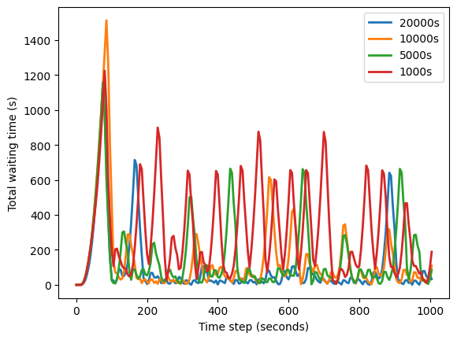

```python
import matplotlib.pyplot as plt
plt.plot(o20000ss['step'], o20000ss['system_total_waiting_time'], label='20000s',linewidth=2)
plt.plot(o10000ss['step'], o10000ss['system_total_waiting_time'], label='10000s',linewidth=2)
plt.plot(o5000ss['step'], o5000ss['system_total_waiting_time'], label='5000s',linewidth=2)
plt.plot(o1000ss['step'], o1000ss['system_total_waiting_time'], label='1000s',linewidth=2)
plt.xlabel('Time step (seconds)')
plt.ylabel('Total waiting time (s)')

plt.legend()
plt.show()
```

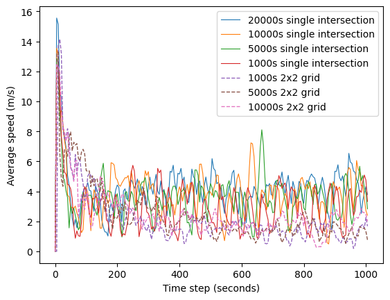

```python
import matplotlib.pyplot as plt
plt.plot(o20000ss['step'], o20000ss['system_mean_speed'], label='20000s single intersection',linewidth=0.8)
plt.plot(o10000ss['step'], o10000ss['system_mean_speed'], label='10000s single intersection',linewidth=0.8)
plt.plot(o5000ss['step'], o5000ss['system_mean_speed'], label='5000s single intersection',linewidth=0.8)
plt.plot(o1000ss['step'], o1000ss['system_mean_speed'], label='1000s single intersection',linewidth=0.8)

plt.plot(o1000ss22['step'], o1000ss22['system_mean_speed'], '--',label='1000s 2x2 grid',linewidth=1)
plt.plot(o5000ss22['step'], o5000ss22['system_mean_speed'],'--', label='5000s 2x2 grid',linewidth=1)
plt.plot(o10000ss22['step'], o10000ss22['system_mean_speed'], '--',label='10000s 2x2 grid',linewidth=1)
plt.xlabel('Time step (seconds)')
plt.ylabel('Average speed (m/s)')

plt.legend()
plt.show()
```

```python
import matplotlib.pyplot as plt
plt.plot(o20000ss['step'], o20000ss['system_total_waiting_time'], label='20000s',linewidth=2)
plt.plot(o10000ss['step'], o10000ss['system_total_waiting_time'], label='10000s',linewidth=2)
plt.plot(o5000ss['step'], o5000ss['system_total_waiting_time'], label='5000s',linewidth=2)
plt.plot(o1000ss['step'], o1000ss['system_total_waiting_time'], label='1000s',linewidth=2)
plt.xlabel('Time step (seconds)')
plt.ylabel('Total waiting time (s)')

plt.legend()
plt.show()
```

[output not shown]

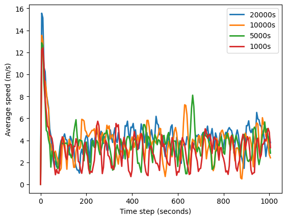

```python
plt.plot(o20000ss['step'], o20000ss['system_mean_speed'], label='20000s',linewidth=2)
plt.plot(o10000ss['step'], o10000ss['system_mean_speed'], label='10000s',linewidth=2)
plt.plot(o5000ss['step'], o5000ss['system_mean_speed'], label='5000s',linewidth=2)
plt.plot(o1000ss['step'], o1000ss['system_mean_speed'], label='1000s',linewidth=2)
plt.xlabel('Time step (seconds)')
plt.ylabel('Average speed (m/s)')

plt.legend()
plt.show()
```

# 2x2 grid

build environment

```python
env = gym.make('sumo-rl-v0',
                net_file='nets/2x2grid/2x2.net.xml',
                route_file='nets/2x2grid/2x2.rou.xml',
                out_csv_name='outputs/2x2grid/',
                use_gui=False,
                num_seconds=1000)
q_array1000ss22 = sarsa(env)
env.save_csv('outputs/2x2grid/output.csv',1)
env.close()
```

```
 Retrying in 1 seconds
Step #0.00 (0ms ?*RT. ?UPS, TraCI: 5ms, vehicles TOT 0 ACT 0 BUF 0)
 Retrying in 1 seconds
```

```
Step #1005.00 (0ms ?*RT. ?UPS, TraCI: 20ms, vehicles TOT 253 ACT 70 BUF 142)
```

test agent

```python
net_file='nets/2x2grid/2x2.net.xml'
route_file='nets/2x2grid/2x2.rou.xml'
output = 'outputs/2x2grid/2x2output1000ss.csv'
evaluate_policy(q_array=q_array1000ss22, net_file=net_file,route_file=route_file,output = output)
```

```
 Retrying in 1 seconds
Step #0.00 (0ms ?*RT. ?UPS, TraCI: 4ms, vehicles TOT 0 ACT 0 BUF 0)
 Retrying in 1 seconds
```

```
Step #1005.00 (0ms ?*RT. ?UPS, TraCI: 16ms, vehicles TOT 243 ACT 65 BUF 150)
```

analyze results

```python
o5000ss22 = pd.read_csv('outputs//2x2grid//teston1000s//2x2output5000ss.csv_conn78_run1.csv')
o10000ss22 = pd.read_csv('outputs//2x2grid//teston1000s//2x2output10000ss.csv_conn79_run1.csv')
o20000ss22 = pd.read_csv('outputs//2x2grid//teston1000s//2x2output20000ss.csv_conn80_run1.csv')
o30000ss22 = pd.read_csv('outputs//2x2grid//teston1000s//2x2output30000ss.csv_conn81_run1.csv')
o1000ss22 = pd.read_csv('outputs/2x2grid/2x2output1000ss.csv_conn93_run1.csv')
```

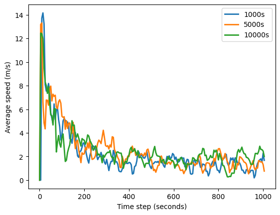

```python
plt.plot(o1000ss22['step'], o1000ss22['system_mean_speed'], label='1000s',linewidth=2)
plt.plot(o5000ss22['step'], o5000ss22['system_mean_speed'], label='5000s',linewidth=2)
plt.plot(o10000ss22['step'], o10000ss22['system_mean_speed'], label='10000s',linewidth=2)
# plt.plot(o20000ss22['step'], o20000ss22['system_mean_speed'], label='20000s',linewidth=2)
# plt.plot(o30000ss22['step'], o30000ss22['system_mean_speed'], label='30000s',linewidth=2)
plt.xlabel('Time step (seconds)')
plt.ylabel('Average speed (m/s)')

plt.legend()
plt.show()
```

```python
print(o1000ss22['system_mean_speed'].mean())
print(o5000ss22['system_mean_speed'].mean())
print(o10000ss22['system_mean_speed'].mean())
```

```
2.2259793902112603
2.484011911800584
2.521531833967232
```

## 2way single intersection

build environment

```python
env = gym.make('sumo-rl-v0',
                net_file='nets/2way-single-intersection/single-intersection.net.xml',
                route_file='nets/2way-single-intersection/single-intersection-vhvh.rou.xml',
                out_csv_name='outputs/single-intersection/',
                use_gui=False,
                num_seconds=10000)
q_array10000ss2w = sarsa(env)
env.save_csv('outputs/2way-single-intersection/output.csv',1)
env.close()
```

test agent

```python
net_file='nets/2way-single-intersection/single-intersection.net.xml'
route_file='nets/2way-single-intersection/single-intersection-vhvh.rou.xml'
output = 'outputs/2way-single-intersection/output10000ss2w.csv'
evaluate_policy(q_array=q_array10000ss2w,net_file=net_file,route_file=route_file,output = output,num_seconds=10000)
```

```
 Retrying in 1 seconds
Step #0.00 (0ms ?*RT. ?UPS, TraCI: 1ms, vehicles TOT 0 ACT 0 BUF 0)
 Retrying in 1 seconds
```

[output not shown]

[figure not shown]

```python
o10000ss2w= pd.read_csv('outputs/2way-single-intersection/output10000ss2w.csv_conn89_run1.csv')
plt.plot(o10000ss2w['step'], o10000ss2w['system_mean_speed'], label='10000s',linewidth=2)
plt.xlabel('Time step (seconds)')
plt.ylabel('Total waiting time (s)')

plt.legend()
plt.show()
```

test_build_env

```python
reward_list = []
num_seconds = 1000
env = gym.make('sumo-rl-v0',
                net_file='nets/single-intersection/single-intersection.net.xml',
                route_file='nets/single-intersection/single-intersection.rou.xml',
                out_csv_name='outputs/single-intersection/output.csv',
                use_gui=False,
                num_seconds=num_seconds)
state, info = env.reset()
done = False
while not done:
    action = greedy_policy( env,q_array,state)
    state, reward,  terminated, truncated, info = env.step(action)
    reward_list.append(reward)
    done = terminated or truncated
env.save_csv('outputs/single-intersection/output.csv',1)
env.close()
```

```
 Retrying in 1 seconds
Step #0.00 (0ms ?*RT. ?UPS, TraCI: 2ms, vehicles TOT 0 ACT 0 BUF 0)
 Retrying in 1 seconds
```

```
Step #1005.00 (1ms ~= 1000.00*RT, ~40000.00UPS, TraCI: 10ms, vehicles TOT 551 ACT 40 BUF 1
```